# peers on childes

AC

7/1/2019

## Intro

In this section, we just read in some info about transcripts in childes, and what participants they contain.

```r
library(childesr)
d_transcripts <- get_transcripts()
```

```
## Using current database version: '2018.1'.
```

```r
alldat=get_speaker_statistics()
```

```
## Using current database version: '2018.1'.
```

```r
merge(alldat,d_transcripts,all.x=T,by="transcript_id")->alldat
length(d_transcripts$filename) #total number of transcripts
```

```
## [1] 34480
```

Next we add a column (type) the classifies each speaker role into adults and peers, and then aggregate the number of sentences for each. At this point, we just want to use these numbers to detect transcripts that contain some peer speech, so there is no reason why sentences rather than word tokens or types are taken. It’s just a first approximation.

I do exclude on purpose experimenter, doctor, clinician, key child – I want to get at transcripts that have a sizable family-and-friends contribution, and exclude those that are mostly with experimenters. Note that “nurse” means babysitter in the UK – so since it’s ambiguous I include it just in case.

```r
alldat$type=NA
alldat$type[alldat$speaker_role %in% c("Brother","Sister","Sibling","Child","Playmate","Boy","Girl","Cousin")] <-"peer"
alldat$type[alldat$speaker_role %in% c("Mother","Adult","Babysitter","Aunt","Caretaker",
                                      "Father","Family_Friend","Grandfather","Grandmother",
                                      "Housekeeper","Nurse","Uncle","Teenager")] <-"adult"
table(alldat$speaker_role)
```

```
##
##           Adult            Aunt      Babysitter             Boy
##            3586             847              70              34
##         Brother Camera_Operator       Caretaker           Child
##            1878             435              87            9222
##       Clinician          Cousin          Doctor     Environment
##              94             830               5              25
##   Family_Friend          Father            Girl     Grandfather
##             150            6335              64             437
##     Grandmother           Group     Housekeeper       Informant
##            1790             183             228             118
##     Interviewer    Investigator            Male           Media
##              90           17481               2               2
##          Mother        Narrator       Non_Human           Nurse
##           18094              22             779             103
##        Observer     Participant         Patient        Playmate
##            1366             523               2             672
##         Sibling          Sister         Speaker         Student
##             106            2279               1             629
##         Subject    Target_Adult    Target_Child         Teacher
##             390             116           32417            1936
##        Teenager       Therapist             Toy       Uncertain
##              17             282             113               2
##           Uncle    Unidentified         Visitor
##             203            2298             440
```

```r
table(alldat$type)
```

```
##
## adult  peer
## 31947 15085
```

```r
sums=aggregate(num_utterances ~type + filename + target_child_id.x, data= alldat,sum)

summary(sums)
```

```
##      type             filename         target_child_id.x num_utterances
##  Length:24917       Length:24917       Min.   :   25     Min.   :   0.0
##  Class :character   Class :character   1st Qu.: 5005     1st Qu.:  23.0
##  Mode  :character   Mode  :character   Median :10418     Median : 134.0
##                                        Mean   :10815     Mean   : 237.9
##                                        3rd Qu.:16548     3rd Qu.: 348.0
##                                        Max.   :20174     Max.   :3544.0
```

```r
mysums=data.frame(sums)
summary(mysums)
```

```
##      type             filename         target_child_id.x num_utterances
##  Length:24917       Length:24917       Min.   :   25     Min.   :   0.0
##  Class :character   Class :character   1st Qu.: 5005     1st Qu.:  23.0
##  Mode  :character   Mode  :character   Median :10418     Median : 134.0
##                                        Mean   :10815     Mean   : 237.9
##                                        3rd Qu.:16548     3rd Qu.: 348.0
##                                        Max.   :20174     Max.   :3544.0
```

```r
adults=subset(mysums,type=="adult")
peers=subset(mysums,type=="peer")
adults$nutt_ad=adults$num_utterances
peers$nutt_peer=peers$num_utterances

adpe=merge(adults[,c("filename","nutt_ad")],peers[,c("filename","nutt_peer","target_child_id.x")],all=T)
adpe$tot=adpe$nutt_ad+adpe$nutt_peer
summary(adpe)
```

```
##    filename            nutt_ad         nutt_peer      target_child_id.x
##  Length:20267       Min.   :   0.0   Min.   :   0.0   Min.   :   25
##  Class :character   1st Qu.:  46.0   1st Qu.:   5.0   1st Qu.: 5005
##  Mode  :character   Median : 178.0   Median :  28.0   Median :15068
##                     Mean   : 274.8   Mean   :  90.5   Mean   :12053
##                     3rd Qu.: 404.0   3rd Qu.: 113.0   3rd Qu.:17684
##                     Max.   :3544.0   Max.   :2961.0   Max.   :20166
##                     NA's   :338      NA's   :15279    NA's   :15279
##       tot
##  Min.   :   0.0
##  1st Qu.: 110.0
##  Median : 222.0
##  Mean   : 338.6
##  3rd Qu.: 425.0
##  Max.   :5266.0
##  NA's   :15617
```

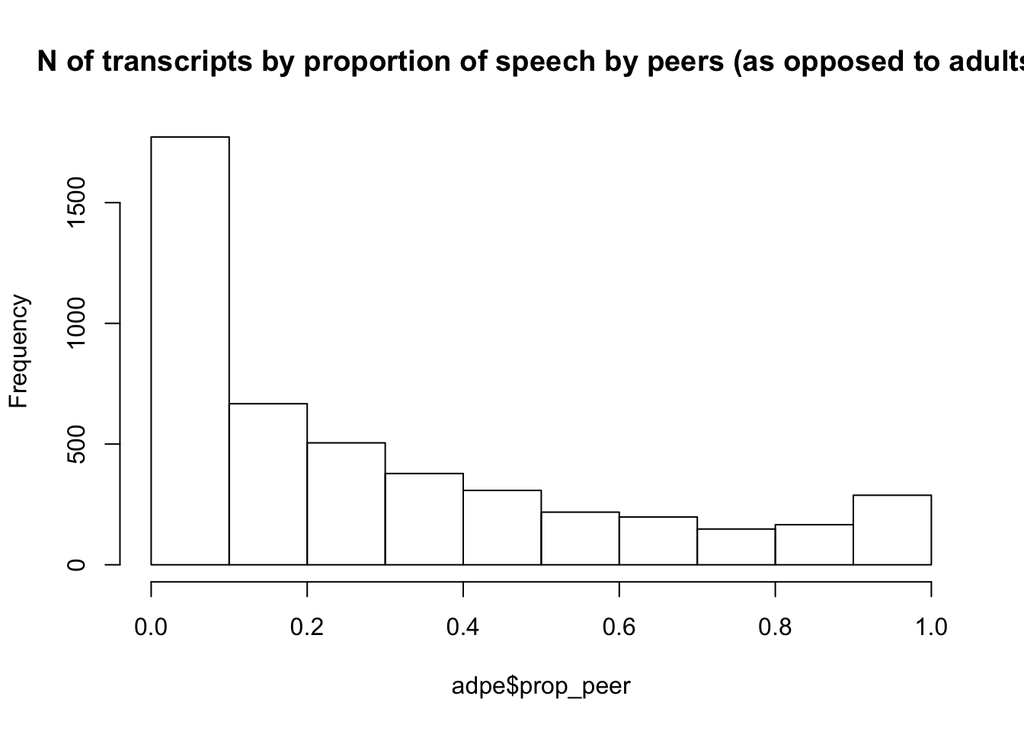

```r
adpe$prop_peer=adpe$nutt_peer/adpe$tot
hist(adpe$prop_peer, main="N of transcripts by proportion of speech by peers (as opposed to adults)")
```

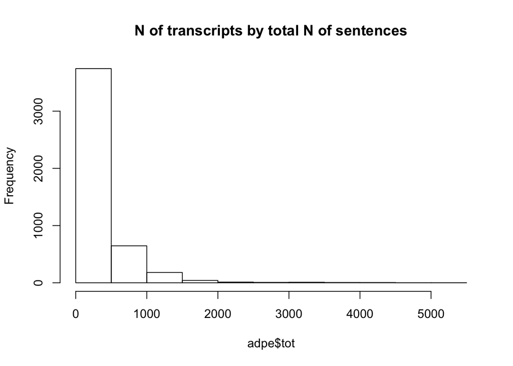

```r
hist(adpe$tot, main="N of transcripts by total N of sentences")
```

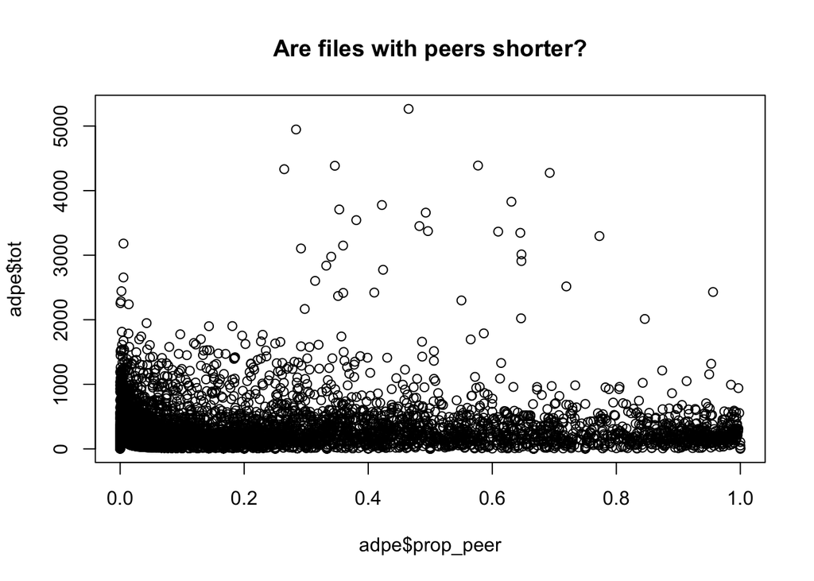

```r
plot(adpe$tot~adpe$prop_peer,main="Are files with peers shorter?")
```

```r
write.table(adpe,"adultsNpeers.txt",row.names = F,sep="\t")
```

For now, a simple selection: only transcripts that have at least .01% of utterances by peers, and at least 300 utterances in total.

```r
adpe$filename[adpe$prop_peer>.0001 & adpe$tot >300 & !is.na(adpe$prop_peer) & !is.na(adpe$tot)]->files_to_include
write.csv(files_to_include,"files_to_include.txt",row.names = F)

length(adpe$filename) #number of transcripts in the analysis, that have some speech by adults and/or some speech by peers
```

```
## [1] 20267
```

```r
length(files_to_include) #number of transcripts that have at least .01% of peer speech & 300 utterances
```

```
## [1] 1726
```

Since we use peer presence to select transcripts, we should ideally revisit the same corpora and extract all other transcripts associated with a child who has been included because their data contains some peer speech.

The following code IS NOT WORKING YET. (bug description: the loop adds too many files, ending up with 500k files!!)

```r
adpe$corpus=gsub("/.*","",adpe$filename)
table(adpe$corpus)
table(adpe$target_child_id.x)

for(thisc in levels(factor(adpe$corpus))){
  thisc_kids=as.factor(adpe$target_child_id.x[adpe$corpus==thisc & !is.na(adpe$corpus) & !is.na(adpe$target_child_id.x)])
  if(length(thisc_kids)>1) for(kid in thisc_kids){
    kid_trans=adpe$filename[adpe$target_child_id.x==kid & !(adpe$filename %in% files_to_include) &
                              !(is.na(adpe$target_child_id.x) & !is.na(adpe$filename))]
    #print(length(kid_trans))
    files_to_include=c(files_to_include,kid_trans)
  }
}


length(files_to_include) #number of transcripts that have at least .01% of peer speech & 300 utterances OR belong to the same child found as having peer speech in a different transcript
write.csv(files_to_include,"files_to_include_extended.txt",row.names = F)
```